# Data and Measurement

# Tutorial 6

In this tutorial we will use the data set “SAQ.sav”. This dataset includes 23 variables measured on a 5-point Likert scale and contains data from 2,571 participants. The items included are:

1. Statistics makes me cry.
2. My friends will think I’m stupid for not being able to cope with SPSS.
3. Standard deviations excite me.
4. I dream that Pearson is attacking me with correlation coefficients.
5. I don’t understand statistics.
6. I have little experience of computers.
7. All computers hate me.
8. I have never been good at mathematics.
9. My friends are better at statistics than me.
10. Computers are useful only for playing games.
11. I did badly at mathematics at school.
12. People try to tell you that SPSS makes statistics easier to understand but it doesn’t.
13. I worry that I will cause irreparable damage because of my incompetenece with computers.
14. Computers have minds of their own and deliberately go wrong whenever I use them.
15. Computers are out to get me.
16. I weep openly at the mention of central tendency.
17. I slip into a coma whenever I see an equation.
18. SPSS always crashes when I try to use it.
19. Everybody looks at me when I use SPSS.
20. I can’t sleep for thoughts of eigen vectors.
21. I wake up under my duvet thinking that I am trapped under a normal distribution.
22. My friends are better at SPSS than I am.
23. If I’m good at statistics my friends will think I’m a nerd.

### Exercise

1. Load the data into the environment. If you use the read.spss function, set the use.value.labels argument to FALSE to avoid converting numeric variables (with value labels) to factors, since the functions we will use (fa()) require numeric variables.

```r
library(foreign)
saq_df <- read.spss("~/Downloads/DS5 SPSS Files/SAQ.sav", to.data.frame = TRUE,
    use.value.labels = FALSE)
```

2. You already know this data set from a previous tutorial, so we will skip the step “Exploring the data set”.

3.Run the Bartlett test for sphericity using the cortest.bartlett function from the psych package. Interpret the results. Note that you can enter the data set (instead of a correlation matrix) directly into the first argument.

```r
psych::cortest.bartlett(saq_df)
```

```
## R was not square, finding R from data
```

```
## $chisq
## [1] 19334.49
##
## $p.value
## [1] 0
##
## $df
## [1] 253
```

The test results are significant, which means that we can reject the null hypothesis that our R matrix is an identity matrix (or that the variables are orthogonal to each other, i.e. not correlated) In other words, we find significant multiple correlations between the variables.

4. Apply the Kaiser-Meyer-Olkin measure using the KMO() function from the psych package. Interpret the results.

```r
psych::KMO(saq_df)
```

```
## Kaiser-Meyer-Olkin factor adequacy
## Call: psych::KMO(r = saq_df)
## Overall MSA =  0.93
## MSA for each item =
## Question_01 Question_02 Question_03 Question_04 Question_05 Question_06
##        0.93        0.87        0.95        0.96        0.96        0.89
## Question_07 Question_08 Question_09 Question_10 Question_11 Question_12
##        0.94        0.87        0.83        0.95        0.91        0.95
## Question_13 Question_14 Question_15 Question_16 Question_17 Question_18
##        0.95        0.97        0.94        0.93        0.93        0.95
## Question_19 Question_20 Question_21 Question_22 Question_23
##        0.94        0.89        0.93        0.88        0.77
```

This is a measure of the proportion of variance between the variables that may be common variance. The higher the proportion, the higher the KMO value, the more suitable the data is for factor analysis.

5. Draw a scree plot using the VSS.scree() function from the psych package. How many factors should be extracted according to the inflexion point?

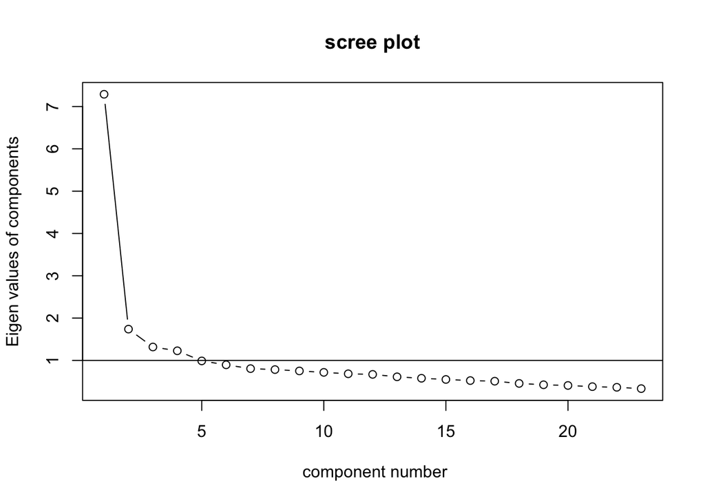

```r
# Scree plot
psych::VSS.scree(saq_df)
```

I accept the inflexion point on the 5th factor, and will therefore ask for a 4-factor solution.

6. Perform an exploratory factor analysis using the fa() function from the psych package. Determine the nfactors to be extracted based on your answer to the previous question. Set the argument fm to “pa” (principal axis factorization), set max.iter = 100 and use an orthogonal rotation (e.g. rotate = “varimax”). Save the results in an object.

```r
saq_fa <- psych::fa(saq_df, nfactors = 4, max.iter = 100, fm = "pa", rotate = "varimax")
```

7. Interpret the results (including the model fit indices). You can use the annotated results from the book by Watkins (2021), e.g. p.93).

According to the results:

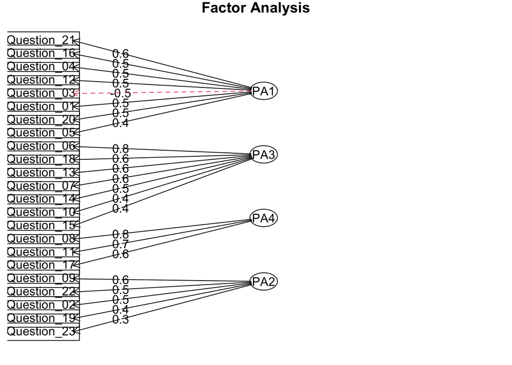

```r
psych::fa.diagram(saq_fa)
```

9. Extract the loadings for the third item (question_3) for all factors, square the loadings and sum them. Does the value match the value in column h2 in the model results? (You can also extract the communalities by entering communality with the $ sign in your saved model results)

```r
# calculate communality
loadings_I3 <- saq_fa$loadings[3, ]  #loadings for third variable (third row of Lambda)
loadings_I3
```

```
##        PA1        PA3        PA4        PA2
## -0.5047526 -0.1805647 -0.1585796  0.3994695
```

```r
communality_I3 <- sum(loadings_I3^2)  #SS of factor loadings
communality_I3
```

```
## [1] 0.4721021
```

```r
saq_fa$communality[3]
```

```
## Question_03
##   0.4721021
```

10. Plot the residuals after extraction using the residuals() function of the psych package (you can set diag = FALSE and na.rm = TRUE). What should we pay attention to in this plot?

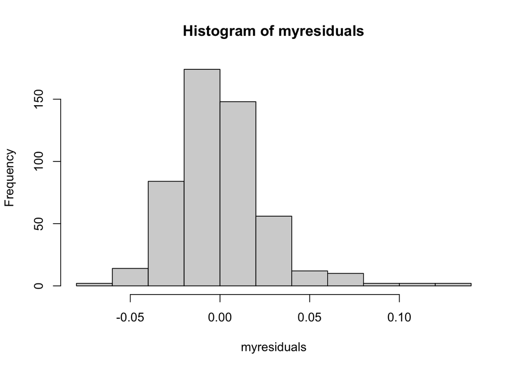

```r
myresiduals <- residuals(saq_fa, diag = FALSE, na.rm = TRUE)
hist(myresiduals)
```

```r
# We look for residuals that are larger than 0.05, as Watkins
# (2021,p.90) states 'Ideally, the proportion of non-redundant
# residual correlations greater than the absolute value of .05 should
# be small'.
sum(abs(myresiduals) > 0.05, na.rm = TRUE)
```

```
## [1] 26
```